# Informe de Avance: Market Justice in Health Care: A 30-Year Study in Chile

Seminario de Título 1: Entrega parcial  
Profesor guía: Juan Carlos Castillo

Autor/a

Cristóbal Mejías

Fecha de publicación

15 de mayo de 2026

# 1 Informe de Avance: Market Justice in Health Care: A 30-Year Study in Chile

## 1.1 Abstract

Las creencias sobre justicia distributiva son fundamentales para la legitimidad de los arreglos sociales. En Chile, el sistema de salud se estructuró bajo un modelo de mercado donde el acceso depende de la capacidad de pago individual, generando una desigualdad estructural que ha tensionado la cohesión social. A pesar de su relevancia, existe un vacío en el estudio longitudinal sobre cómo ha evolucionado la aceptación ciudadana de esta mercantilización.

Esta investigación analiza la evolución de la “justicia de mercado” en salud en Chile entre 1999 y 2019, evaluando el impacto de la percepción de privilegio, el criterio de necesidad, la brecha salarial percibida y la posición socioeconómica. Utilizando datos de tres olas del International Social Survey Programme (ISSP) (1999, 2009 y 2019), se emplean modelos de regresión logística para identificar los determinantes del apoyo a la desigualdad sanitaria. El estudio busca determinar si la legitimidad del mercado ha declinado ante una mayor conciencia de las brechas estructurales o si persiste mediante la naturalización de las barreras de acceso.

## 1.2 Introducción

El sistema de salud chileno experimentó una transformación estructural radical durante la dictadura cívico-militar (1973-1989), estableciendo un modelo de corte neoliberal que privatizó y mercantilizó el acceso a los servicios de bienestar (Bastías, 2023; Llambías-Wolff, 2019; Madariaga, 2020). Este cambio de paradigma reemplazó el principio de acceso basado en la necesidad por uno determinado estrictamente por la cacidad de pago individual, dando origen a un sistema segmentado y fragmentado que dividió la provisión entre alternativas privadas excluyentes para los sectores de mayores ingresos y un sector público restrictivo para las clases de menores recursos (Bastías, 2023; Castillo et al., 2025; Llambías-Wolff, 2019). A pesar del retorno a la democracia, los gobiernos de la coalición de centro-izquierda mantuvieron intactos los cimientos de este modelo de mercado, constreñidos por el diseño institucional heredado y la presión de los grupos de interés empresariales, limitándose a implementar reformas progresivas pero no estructurales (Llambías-Wolff, 2019; Madariaga, 2020). A lo largo de tres décadas, la persistencia de esta desigualdad estructural operó como un catalizador de conflicto social, cuyo punto de inflexión insoslayable se materializó en el estallido social de octubre de 2019, impulsado por el rechazo popular a la precariedad del bienestar y a la alta dependencia del gasto de bolsillo. En este contexto, el estudio de los últimos treinta años —y en particular del período 1999-2019— resulta fundamental para analizar cómo ha evolucionado la legitimidad y la justificación ciudadana respecto a la mercantilización de la salud en un entorno de marcadas disparidades socioeconómicas.

**La pregunta de investigación:**

*¿Cómo ha evolucionado la aceptación de la justicia de mercado en la atención de salud en Chile entre 1999 y 2019, y qué papel juegan la percepción de privilegio, la necesidad, la brecha salarial percibida y la posición socioeconómica en explicar esa evolución?*

En cuanto a los objetivos de esta investigación:

**Objetivo general**

Analizar la evolución de la aceptación de la justicia de mercado en la atención de salud en Chile entre 1999 y 2019, examinando el rol de la percepción de privilegio, la necesidad, la brecha salarial percibida y la posición socioeconómica como factores explicativos.

**Objetivos específicos**

1. **Describir** cómo ha cambiado la distribución de la aceptación de la desigualdad en la atención de salud en Chile a lo largo de las tres olas (1999, 2009, 2019).
2. **Examinar** la relación entre la percepción de privilegio y la aceptación de la justicia de mercado en la atención de salud en cada período.
3. **Analizar** en qué medida el criterio de necesidad se asocia con la aceptación de la justicia de mercado en la atención de salud en las distintas olas.
4. **Examinar** la relación entre la brecha salarial percibia y la aceptación de la justicia de mercado en la atención de salud en cada periodo.
5. **Analizar** en qué medida la posición socioeconómica se asocia con la aceptación de la desigualdad en la atención de salud según su periodo
6. **Evaluar** si la relación entre los factores explicativos y la aceptación de la desigualdad en atención de salud varía según el período histórico considerado.

## 1.3 Antecedentes

### 1.3.1 Market Justice Health Care

La justicia de mercado se define como un principio normativo que legitima la distribución de servicios esenciales, como la salud, en función del mérito individual y la capacidad de pago, asumiendo al mercado como un espacio neutral en contraposición a la “justicia política” orientada por la igualdad ciudadana y la necesidad social (Castillo et al., 2025; Lindh, 2017). La aceptación ciudadana de este principio está fuertemente determinada por el diseño institucional a nivel macroestructural (Immergut & Schneider, 2020). En sistemas sanitarios con alta dependencia del financiamiento privado y fuertes barreras de costo, la desigualdad tiende a naturalizarse como un “estándar existencial”, disminuyendo la percepción de injusticia frente al hecho de que los sectores de mayores ingresos compren tratamientos superiores (Immergut & Schneider, 2020). En estos escenarios, la consolidación de alternativas privadas fomenta que las clases medias y altas abandonen el apoyo a los sistemas universales para asegurar su propio acceso excluyente, elevando el respaldo general a las lógicas de privatización (Busemeyer & Iversen, 2020; Lindh, 2017).

A nivel microindividual, el apoyo a la justicia de mercado está condicionado por la posición socioeconómica y los marcos de creencias normativas (Castillo et al., 2025). Las personas en posiciones ventajosas muestran sistemáticamente un mayor respaldo a la asignación mediante el mercado para defender sus privilegios materiales e intereses de clase (Lindh, 2017). Sin embargo, la legitimidad del modelo decae cuando los individuos perciben que la brecha de desigualdad económica es excesiva, especialmente en dimensiones clave como la salud y la educación, las cuales generan una intolerancia significativamente mayor que las simples disparidades salariales (Castillo et al., 2025; Soler-Martínez et al., 2025). Pese a ello, esta visión crítica es fuertemente contrarrestada por la ideología meritocrática: quienes creen firmemente que la sociedad premia el esfuerzo personal son propensos a justificar el acceso desigual a la salud, interpretando las ventajas sanitarias exclusivas como una recompensa moralmente merecida por el éxito económico individual (Castillo et al., 2026).

### 1.3.2 Factores asociados

El ideal meritocrático ha operado históricamente como un principio normativo central para legitimar las desigualdades, asumiendo que el éxito económico y las ventajas sociales son el resultado justo del esfuerzo y el talento individual (Fehr & Vollmann, 2025; Friedman et al., 2024) Sin embargo, la legitimidad de este discurso se fractura cuando se introduce en la ecuación la percepción del privilegio y la conciencia de los factores estructurales. La evidencia empírica demuestra que cuando las ventajas económicas y el éxito se atribuyen a factores de origen —como la herencia familiar, las circunstancias externas o el simple azar— en lugar del mérito personal, la justificación moral de la desigualdad disminuye de manera sustancial (Fehr & Vollmann, 2025; Sachweh & Eicher, 2025). En este sentido, el reconocimiento de que el acceso a un bienestar superior obedece a un origen social privilegiado revela las fallas estructurales de un sistema que asume erróneamente al mercado como una arena neutral, operando como un contrapeso crítico a la narrativa de la meritocracia (Sachweh & Eicher, 2025).

La evaluación ciudadana sobre estas asimetrías no solo juzga la legitimidad de la riqueza, sino también quién es digno de recibir protección social, un proceso estructurado mediante juicios de merecimiento (deservingness) (Kootstra, 2016; Van Oorschot & Roosma, 2017). El modelo CARIN establece los criterios centrales para entender estas dinámicas, entre los cuales el control sobre la situación de necesidad es fundamental: los individuos son considerados menos merecedores de ayuda estatal si se les percibe como personalmente responsables de su propia precariedad (Kootstra, 2016; Van Oorschot & Roosma, 2017). No obstante, este mismo marco permite relevar el criterio de la necesidad. Bajo este parámetro normativo, las personas que exhiben mayores niveles de urgencia objetiva o carencia material son consideradas inherentemente más merecedoras de apoyo y solidaridad colectiva (Kootstra, 2016; Van Oorschot & Roosma, 2017). De este modo, el principio de la necesidad se erige como un fundamento básico de la justicia distributiva enfocado en aliviar las carencias humanas, operando mediante una lógica de asignación opuesta a la exclusión por capacidad de pago propia del mercado (Van Hootegem et al., 2020).

La evaluación subjetiva de las brechas de desigualdad es fundamental para legitimar o rechazar la justicia de mercado. Cuando los individuos perciben que la magnitud de la desigualdad es excesiva, su apoyo a que el acceso a servicios esenciales dependa de la capacidad de pago disminuye significativamente (Castillo et al., 2025). Esta postura crítica se intensifica al evaluar asimetrías en dimensiones vitales como la salud y la educación, las cuales generan una intolerancia mucho mayor y movilizan más respaldo a políticas redistributivas que las simples diferencias salariales (Soler-Martínez et al., 2025). En consecuencia, una conciencia aguda de estas disparidades erosiona la eficacia de los discursos meritocráticos, evidenciando que las ventajas acumuladas responden más a privilegios estructurales que al esfuerzo personal (Sachweh & Eicher, 2025).

En cuanto a la posición socioeconómica, los grupos de mayores ingresos justifican sus ventajas con narrativas meritocráticas (Fehr & Vollmann, 2025) y prefieren alternativas privadas, distanciándose de la provisión pública (Busemeyer & Iversen, 2020). Aunque la individualización del modelo apacigua el reclamo social colectivo contra la mercantilización, los sectores desfavorecidos rechazan con mayor fuerza esta exclusión generada por el mercado (Immergut & Schneider, 2020).

**Diagrama de Hipótesis**

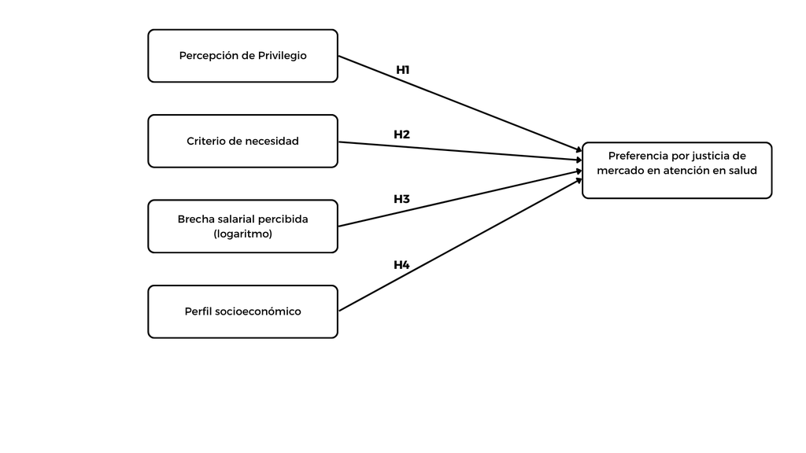

**H1: A mayor percepción de privilegio, menor preferencia por justicia de mercado en salud**

**H2: A mayor creencia en el criterio de necesidad, menor será la preferencia por la justicia de mercado en salud**

**H3: A mayor percepción de brecha salarial, menor preferencia por justicia de mercado en salud**

**H4: A mayor posición socioeconómica, mayor preferencia por justicia de mercado en salud**

## 1.4 Metodología

Para ver una resumen de las variables ir a Tabla Variables.

# 2 Procesamiento de datos

## 2.1 Librerías y configuraciones iniciales

```r
library(pacman)

pacman::p_load(haven, tidyverse, dplyr, car, recode, sjlabelled, summarytools, sjmisc, sjPlot, ggplot2, knitr, kableExtra, webshot2, gt)


options(scipen = 999)
rm(list = ls())
```

## 2.2 Cargar bases de la ISSP

```r
issp99<-read_dta("input/data/issp1999.dta")
issp09<-read_dta("input/data/issp2009.dta")
issp19<-read_dta("input/data/issp2019.dta")
```

## 2.3 Procesamiento ISSP 1999

```r
issp99_r <- issp99 |>
  filter(v3==30) |>
  select(
    v39,             # VD: market justice salud
    v4, v5,          # percepción privilegio: familia rica, contactos
    v53,             # Criterio de necesidad: tener hijos
    v21, v16,        # ingresos percibidos: obrero y gerente (brutos)
    x_degr,          # educación
    v46,             # estatus social subjetivo
    sex, age,        # sexo, edad
    income,          # ingreso familiar
    hompop,          # cantidad de personas en el hogar
    party_lr         # posición política
  )

view_df(issp99_r, max.len = 100)
```

### 2.3.1 Tratamiento: market justice salud

```r
descr(issp99_r$v39)
frq(issp99_r$v39)

issp99_r <- issp99_r |>
  mutate(
    mjs = car::recode(v39, "1=5; 2=4; 3=3; 4=2; 5=1; c(8,9)=NA", as.numeric = TRUE),
    mjs = set_labels(mjs, labels = c(
      "Muy en desacuerdo" = 1,
      "En desacuerdo" = 2,
      "Ni de acuerdo ni en desacuerdo" = 3,
      "De acuerdo" = 4,
      "Muy de acuerdo" = 5
    ))
  ) |>
  var_labels(mjs = "Preferencia por justicia de mercado en salud")

descr(issp99_r$mjs)
frq(issp99_r$mjs)
```

### 2.3.2 Tratamiento: Percepción de privilegio

```r
frq(issp99_r$v4)
frq(issp99_r$v5)

# Tratamiendo de V4
issp99_r <- issp99_r |>
  mutate(
    v4_r = car::recode(v4, "1=5; 2=4; 3=3; 4=2; 5=1; c(8,9)=NA", as.numeric = TRUE),
    v4_r = set_labels(v4_r, labels = c(
      "No tiene importancia alguna" = 1,
      "No es muy importante" = 2,
      "Algo importante" = 3,
      "Muy importante" = 4,
      "Esencial" = 5
    ))
  ) |>
  var_labels(v4_r = "Importancia de provenir de una familia rica para surgir en la vida")

# Tratamiendo de V5
issp99_r <- issp99_r |>
  mutate(
    v5_r = car::recode(v5, "1=5; 2=4; 3=3; 4=2; 5=1; c(8,9)=NA", as.numeric = TRUE),
    v5_r = set_labels(v5_r, labels = c(
      "No tiene importancia alguna" = 1,
      "No es muy importante" = 2,
      "Algo importante" = 3,
      "Muy importante" = 4,
      "Esencial" = 5
    ))
  ) |>
  var_labels(v5_r = "Importancia de tener contactos para surgir en la vida")

frq(issp99_r$v4_r)
frq(issp99_r$v5_r)

# Crear índice de privilegio
issp99_r <- issp99_r |>
  mutate(
    privilege = v4_r + v5_r,
    privilege = privilege - 1
  ) |>
  var_labels(
    privilege = "Percepción de Privilegio"
  )

descr(issp99_r$privilege)
frq(issp99_r$privilege)
```

### 2.3.3 Tratamiento: Criterio de necesidad

```r
descr(issp99_r$v53)
frq(issp99_r$v53)

issp99_r <- issp99_r |>
  mutate(
    necessity = car::recode(v53, "1=5; 2=4; 3=3; 4=2; 5=1; c(8,9)=NA", as.numeric = TRUE),
    necessity = set_labels(necessity, labels = c(
      "No tiene importancia alguna" = 1,
      "No es muy importante" = 2,
      "Algo importante" = 3,
      "Muy importante" = 4,
      "Esencial" = 5
    ))
  ) |>
  var_labels(necessity = "Importancia de tener hijos que mantener para decidirse la remuneración")

descr(issp99_r$necessity)
frq(issp99_r$necessity)
```

### 2.3.4 Tratamiento: Brecha salarial percibida

```r
# Visualizar ingreso obrero
frq(issp99_r$v21)
summary(issp99_r$v21)

# Visualizar ingreso gerente
frq(issp99_r$v16)
summary(issp99_r$v16)

# Crear gap
issp99_r <- issp99_r |>
  mutate(
    inc_obrero = if_else(v21 > 40000 & v21 < 1000000, v21, NA_real_),
    inc_gerente = if_else(v16 > 250000 & v16 < 100000001, v16, NA_real_),

    gap_perc   = inc_gerente / inc_obrero,
    lngap_perc = log(gap_perc)
  )|>
  var_labels(lngap_perc = "Brecha salarial percibida (logaritmo)")


# Visualizar ingreso gap
frq(issp99_r$lngap_perc)
summary(issp99_r$lngap_perc)
```

### 2.3.5 Tratamiento: Perfil socioeconómico

```r
# 1. Educación

frq(issp99_r$x_degr)

issp99_r <- issp99_r |>
  mutate(
    educ = case_when(
      x_degr >= 3001 & x_degr <= 3006 ~ 0,
      x_degr >= 3007 & x_degr <= 3008 ~ 1,
      TRUE                           ~ NA_real_
    )
  ) |>
  sjlabelled::var_labels(
    educ  = "Nivel educacional (Dicotómica: Universitario)"
  ) |>
  set_labels( educ, labels = c(
    "No universitario" = 0,
    "Universitario" = 1)
  )

frq(issp99_r$educ)

# 2. Estatus social subjetivo

frq(issp99_r$v46)

issp99_r <- issp99_r |>
  mutate(
    ess = case_when(v46 >= 97 ~ NA_real_, TRUE ~ as.numeric(v46)
    ),
    ess = rec(ess, rec = "rev")
  ) |>
  var_labels(
    ess = "Estatus social subjetivo"
  )

frq(issp99_r$ess)

# 3. Sexo

sjmisc::frq(issp99_r$sex)

issp99_r <- issp99_r |>
  mutate(
    sex = set_labels(sex, labels = c(
      "Hombre" = 1,
      "Mujer" = 2)
  )
)

frq(issp99_r$sex)

# 4. Edad

issp99_r <- issp99_r |>
  mutate(
    edad = case_when(
      age<= 29 ~ "Jovenes",
      age>= 30 & age <= 59 ~ "Adultos",
      age >= 60 ~ "Adultos mayores")
  ) |>
   var_labels(
    edad = "Edad (tramos)"
  )

frq(issp99_r$edad)
```

### 2.3.6 Tratamiento: Ingresos

```r
# Tratamiento de ingreso total del hogar (en tramos)
sjmisc::frq(issp99_r$income,
            out = "txt",
            show.na = T) |> knitr::kable()

issp99_r <- issp99_r |>
  mutate(
    income_r = case_when(
      income >= 999997 ~ NA_real_,
      TRUE             ~ as.numeric(income)
    )
  )

sjmisc::frq(issp99_r$income_r,
            out = "txt",
            show.na = T) |> knitr::kable()

# Sacar media del tramo
issp99_r <- issp99_r |>
  mutate(income_med = case_when(
    income_r == 1  ~ 90000,
    income_r == 2  ~ (91000  + 120000) / 2,
    income_r == 3  ~ (121000 + 150000) / 2,
    income_r == 4  ~ (151000 + 180000) / 2,
    income_r == 5  ~ (181000 + 210000) / 2,
    income_r == 6  ~ (211000 + 240000) / 2,
    income_r == 7  ~ (241000 + 290000) / 2,
    income_r == 8  ~ (291000 + 390000) / 2,
    income_r == 9  ~ (391000 + 600000) / 2,
    income_r == 10 ~ (601000 + 1000000) / 2,
    income_r == 11 ~ (1000001 + 1500000) / 2,
    income_r == 12 ~ (1500001 + 2000000) / 2,
    income_r == 13 ~ (2000001 + 3000000) / 2,
    income_r == 14 ~ 3000000,
    TRUE           ~ NA_real_
  ))

# Per cápita

issp99_r <- issp99_r |>
  mutate(ing_pcap = income_med / hompop,
         ing_pcap = sjlabelled::set_label(ing_pcap, label = "Ingreso per cápita"))

# Visualizar ingresos per cápita
sjmisc::descr(issp99_r$ing_pcap,
              show = c("label", "n", "NA.prc", "mean", "md")) |>
  knitr::kable(digits = 0)

sjmisc::frq(issp99_r$ing_pcap,
            out = "txt",
            show.na = T) |> knitr::kable()
```

### 2.3.7 Tratamiento: Año

```r
issp99_r <- issp99_r |>
  mutate(year = 1999)

issp99_r$year <- sjlabelled::set_label(issp99_r$year, label = "Año de la encuesta")

frq(issp99_r$year)
```

### 2.3.8 Visualizar NA y Guardar

```r
# Visualizar NA
sum(is.na(issp99_r))
colSums(is.na(issp99_r)) #La mayor pérdida de casos se debe a el ingreso percibido de los gerentes
na_issp99 <- na.omit(issp99_r)

# Guardar BBDD

save(issp99_r,file = here::here("input/data/proc/data99.RData"))
```

## 2.4 Procesamiento ISSP 2009

```r
issp09_r <- issp09 |>
  filter(V4==152) |>
  select(
    V38,             # VD: market justice salud
    V6, V11,         # percepción privilegio: familia rica, contactos
    V50,             # Criterio de necesidad: tener hijos
    V25, V23,        # ingresos percibidos: obrero y gerente (brutos)
    CL_DEGR,         # educación
    V44,             # estatus social subjetivo
    SEX, AGE,        # sexo, edad
    CL_INC,          # ingreso familiar
    HOMPOP,          # cantidad de personas en el hogar
    CL_PRTY,         # posición política
  )

view_df(issp09_r, max.len = 100)
```

### 2.4.1 Tratamiento: Market justice salud

```r
sjmisc::frq(issp09_r$V38,
            out = "txt",
            show.na = T) |> knitr::kable()


issp09_r <- issp09_r |>
  mutate(
    mjs = car::recode(V38, "1=5; 2=4; 3=3; 4=2; 5=1; c(8,9)=NA", as.numeric = TRUE),
    mjs = set_labels(mjs, labels = c(
      "Muy en desacuerdo" = 1,
      "En desacuerdo" = 2,
      "Ni de acuerdo ni en desacuerdo" = 3,
      "De acuerdo" = 4,
      "Muy de acuerdo" = 5
    ))
  ) |>
  var_labels(mjs = "Preferencia por justicia de mercado en salud")

sjmisc::frq(issp09_r$mjs,
            out = "txt",
            show.na = T) |> knitr::kable()
```

### 2.4.2 Tratamiento: Percepción de privilegio

```r
frq(issp09_r$V6)
frq(issp09_r$V11)

# Tratamiendo de V6
issp09_r <- issp09_r |>
  mutate(
    v6_r = car::recode(V6, "1=5; 2=4; 3=3; 4=2; 5=1; c(8,9)=NA", as.numeric = TRUE),
    v6_r = set_labels(v6_r, labels = c(
      "No tiene importancia alguna" = 1,
      "No es muy importante" = 2,
      "Algo importante" = 3,
      "Muy importante" = 4,
      "Esencial" = 5
    ))
  ) |>
  var_labels(v6_r = "Importancia de provenir de una familia rica para surgir en la vida")

# Tratamiendo de V11
issp09_r <- issp09_r |>
  mutate(
    v11_r = car::recode(V11, "1=5; 2=4; 3=3; 4=2; 5=1; c(8,9)=NA", as.numeric = TRUE),
    v11_r = set_labels(v11_r, labels = c(
      "No tiene importancia alguna" = 1,
      "No es muy importante" = 2,
      "Algo importante" = 3,
      "Muy importante" = 4,
      "Esencial" = 5
    ))
  ) |>
  var_labels(v11_r = "Importancia de tener contactos para surgir en la vida")

frq(issp09_r$v6_r)
frq(issp09_r$v11_r)

# Crear índice de privilegio
issp09_r <- issp09_r |>
  mutate(
    privilege = v6_r + v11_r,
    privilege = privilege - 1
  ) |>
  var_labels(
    privilege = "Percepción de Privilegio"
  )

descr(issp09_r$privilege)
frq(issp09_r$privilege)
```

### 2.4.3 Tratamiento: Criterio de necesidad

```r
descr(issp09_r$V50)
frq(issp09_r$V50)

issp09_r <- issp09_r |>
  mutate(
    necessity = car::recode(V50, "1=5; 2=4; 3=3; 4=2; 5=1; c(8,9)=NA", as.numeric = TRUE),
    necessity = set_labels(necessity, labels = c(
      "No tiene importancia alguna" = 1,
      "No es muy importante" = 2,
      "Algo importante" = 3,
      "Muy importante" = 4,
      "Esencial" = 5
    ))
  ) |>
  var_labels(necessity = "Importancia de tener hijos que mantener para decidirse la remuneración")

descr(issp09_r$necessity)
frq(issp09_r$necessity)
```

### 2.4.4 Tratamiento: Brecha salarial percibida

```r
# Visualizar ingreso obrero
frq(issp09_r$V25)
summary(issp09_r$V25)

# Visualizar ingreso gerente
frq(issp09_r$V23)
summary(issp09_r$V23)

# Crear gap
issp09_r <- issp09_r |>
  mutate(
    inc_obrero = if_else(V25 > 40000 & V25 < 1000000, V25, NA_real_),
    inc_gerente = if_else(V23 > 250000 & V23 < 100000001, V23, NA_real_),

    gap_perc   = inc_gerente / inc_obrero,
    lngap_perc = log(gap_perc)
  ) |>
  var_labels(lngap_perc = "Brecha salarial percibida (logaritmo)")


# Visualizar ingreso gap
frq(issp09_r$lngap_perc)
summary(issp09_r$lngap_perc)
```

### 2.4.5 Tratamiento: Perfil socioeconómico

```r
# 1. Educación

frq(issp09_r$CL_DEGR)

issp09_r <- issp09_r |>
  mutate(
    educ = case_when(
      CL_DEGR == 7 ~ 1,
      CL_DEGR >= 1 & CL_DEGR <= 9 ~ 0,
      TRUE                        ~ NA_real_
    )
  ) |>
  sjlabelled::var_labels(
    educ = "Nivel educacional (Dicotómica: Universitario)"
  ) |>
  sjlabelled::set_labels(educ, labels = c(
    "No universitario" = 0,
    "Universitario" = 1
  ))

frq(issp09_r$educ)

# 2. Estatus social subjetivo

frq(issp09_r$V44)

issp09_r <- issp09_r |>
  mutate(
    ess = case_when(V44 >= 97 ~ NA_real_, TRUE ~ as.numeric(V44)
    )
  ) |>
  var_labels(
    ess = "Estatus social subjetivo"
  )

frq(issp09_r$ess)

# 3. Sexo

sjmisc::frq(issp09_r$SEX)

issp09_r <- issp09_r |>
  mutate(
    sex = set_labels(SEX, labels = c(
      "Hombre" = 1,
      "Mujer" = 2)
  )
)

frq(issp09_r$sex)

# 4. Edad

issp09_r <- issp09_r |>
  mutate(
    edad = case_when(
      AGE<= 29 ~ "Jovenes",
      AGE>= 30 & AGE <= 59 ~ "Adultos",
      AGE >= 60 ~ "Adultos mayores")
  ) |>
   var_labels(
    edad = "Edad (tramos)"
  )

frq(issp09_r$edad)
```

### 2.4.6 Tratamiento: Ingresos

```r
# Tratamiento de ingreso total del hogar (en tramos)
sjmisc::frq(issp09_r$CL_INC,
            out = "txt",
            show.na = T) |> knitr::kable()

issp09_r <- issp09_r |>
  mutate(
    income_r = case_when(
      CL_INC >= 9999990 ~ NA_real_,
      TRUE             ~ as.numeric(CL_INC)
    )
  )

sjmisc::frq(issp09_r$income_r,
            out = "txt",
            show.na = T) |> knitr::kable()

# Per cápita

issp09_r <- issp09_r |>
  mutate(ing_pcap = income_r / HOMPOP,
         ing_pcap = sjlabelled::set_label(ing_pcap, label = "Ingreso per cápita"))

# Visualizar ingresos per cápita
sjmisc::descr(issp09_r$ing_pcap,
              show = c("label", "n", "NA.prc", "mean", "md")) |>
  knitr::kable(digits = 0)

sjmisc::frq(issp09_r$ing_pcap,
            out = "txt",
            show.na = T) |> knitr::kable()
```

### 2.4.7 Tratamiento: Año

```r
issp09_r <- issp09_r |>
  mutate(year = 2009)

issp09_r$year <- sjlabelled::set_label(issp09_r$year, label = "Año de la encuesta")

frq(issp09_r$year)
```

### 2.4.8 Visualizar NA y Guardar

```r
# Visualizar NA
sum(is.na(issp09_r))
colSums(is.na(issp09_r)) #La mayor pérdida de casos se debe a el ingreso total del hogar
na_issp09 <- na.omit(issp09_r)

# Guardar BBDD

save(issp09_r,file = here::here("input/data/proc/data09.RData"))
```

## 2.5 Procesamiento ISSP 2019

```r
issp19_r <- issp19 |>
  filter(country==152) |>
  select(
    v30,             # VD: market justice salud
    v1, v5,          # percepción privilegio: familia rica, contactos
    v46,             # Criterio de necesidad: tener hijos
    v14, v12,        # ingresos percibidos: obrero y gerente (brutos)
    CL_DEGR,         # educación
    TOPBOT,          # estatus social subjetivo
    SEX, AGE,        # sexo, edad
    CL_INC,          # ingreso familiar
    HOMPOP,          # cantidad de personas en el hogar
    CL_PRTY,         # posición política
  )

view_df(issp19_r, max.len = 100)
```

### 2.5.1 Tratamiento: Market justice salud

```r
sjmisc::frq(issp19_r$v30,
            out = "txt",
            show.na = T) |> knitr::kable()


issp19_r <- issp19_r |>
  mutate(
    mjs = car::recode(v30, "1=5; 2=4; 3=3; 4=2; 5=1; c(-8,-9)=NA", as.numeric = TRUE),
    mjs = set_labels(mjs, labels = c(
      "Muy en desacuerdo" = 1,
      "En desacuerdo" = 2,
      "Ni de acuerdo ni en desacuerdo" = 3,
      "De acuerdo" = 4,
      "Muy de acuerdo" = 5
    ))
  ) |>
  var_labels(mjs = "Preferencia por justicia de mercado en salud")

sjmisc::frq(issp19_r$mjs,
            out = "txt",
            show.na = T) |> knitr::kable()
```

### 2.5.2 Tratamiento: Percepción de privilegio

```r
frq(issp19_r$v1)
frq(issp19_r$v5)

# Tratamiendo de v1
issp19_r <- issp19_r |>
  mutate(
    v1_r = car::recode(v1, "1=5; 2=4; 3=3; 4=2; 5=1; c(-8,-9)=NA", as.numeric = TRUE),
    v1_r = set_labels(v1_r, labels = c(
      "No tiene importancia alguna" = 1,
      "No es muy importante" = 2,
      "Algo importante" = 3,
      "Muy importante" = 4,
      "Esencial" = 5
    ))
  ) |>
  var_labels(v1_r = "Importancia de provenir de una familia rica para surgir en la vida")

# Tratamiendo de v5
issp19_r <- issp19_r |>
  mutate(
    v5_r = car::recode(v5, "1=5; 2=4; 3=3; 4=2; 5=1; c(-8,-9)=NA", as.numeric = TRUE),
    v5_r = set_labels(v5_r, labels = c(
      "No tiene importancia alguna" = 1,
      "No es muy importante" = 2,
      "Algo importante" = 3,
      "Muy importante" = 4,
      "Esencial" = 5
    ))
  ) |>
  var_labels(v5_r = "Importancia de tener contactos para surgir en la vida")

frq(issp19_r$v1_r)
frq(issp19_r$v5_r)

# Crear índice de privilegio
issp19_r <- issp19_r |>
  mutate(
    privilege = v1_r + v5_r,
    privilege = privilege - 1
  ) |>
  var_labels(
    privilege = "Percepción de Privilegio"
  )

descr(issp19_r$privilege)
frq(issp19_r$privilege)
```

### 2.5.3 Tratamiento: Criterio de necesidad

```r
descr(issp19_r$v46)
frq(issp19_r$v46)

issp19_r <- issp19_r |>
  mutate(
    necessity = car::recode(v46, "1=5; 2=4; 3=3; 4=2; 5=1; c(-1,-8,-9)=NA", as.numeric = TRUE),
    necessity = set_labels(necessity, labels = c(
      "No tiene importancia alguna" = 1,
      "No es muy importante" = 2,
      "Algo importante" = 3,
      "Muy importante" = 4,
      "Esencial" = 5
    ))
  ) |>
  var_labels(necessity = "Importancia de tener hijos que mantener para decidirse la remuneración")

descr(issp19_r$necessity)
frq(issp19_r$necessity)
```

### 2.5.4 Tratamiento: Brecha salarial percibida

```r
# Visualizar ingreso obrero
frq(issp19_r$v14)
summary(issp19_r$v14)

# Visualizar ingreso gerente
frq(issp19_r$v12)
summary(issp19_r$v12)


issp19_r <- issp19_r |>
  mutate(
    v14_r = if_else(v14 < 0, NA_real_, v14),
    v12_r = if_else(v12 < 0, NA_real_, v12),

    inc_obrero = if_else(v14_r > 40000 & v14_r < 1000000, v14_r, NA_real_),
    inc_gerente = if_else(v12_r > 250000 & v12_r < 100000001, v12_r, NA_real_),

    # 3. Calcular el gap y el logaritmo
    gap_perc   = inc_gerente / inc_obrero,
    lngap_perc = log(gap_perc)
  ) |>
  var_labels(lngap_perc = "Brecha salarial percibida (logaritmo)")


# Visualizar ingreso gap
frq(issp19_r$lngap_perc)
summary(issp19_r$lngap_perc)
```

### 2.5.5 Tratamiento: Perfil socioeconómico

```r
# 1. Educación

frq(issp19_r$CL_DEGR)

issp19_r <- issp19_r |>
  mutate(educ = case_when(
    CL_DEGR %in% c(-2, -9) ~ NA_real_,
    CL_DEGR >= 9           ~ 1,
    CL_DEGR >= 1 & CL_DEGR <= 8 ~ 0,
    TRUE                   ~ NA_real_
  )) |>
  sjlabelled::var_labels(
    educ = "Nivel educacional (Dicotómica: Universitario)"
  ) |>
  sjlabelled::set_labels(educ, labels = c(
    "No universitario" = 0,
    "Universitario" = 1
  ))

frq(issp19_r$educ)

# 2. Estatus social subjetivo

frq(issp19_r$TOPBOT)

issp19_r <- issp19_r |>
  mutate(
    ess = case_when(TOPBOT < 0 ~ NA_real_, TRUE ~ as.numeric(TOPBOT)
    )
  ) |>
  var_labels(
    ess = "Estatus social subjetivo"
  )

frq(issp19_r$ess)

# 3. Sexo

sjmisc::frq(issp19_r$SEX)

issp19_r <- issp19_r |>
  mutate(
    sex = set_labels(SEX, labels = c(
      "Hombre" = 1,
      "Mujer" = 2)
  )
)

frq(issp19_r$sex)

# 4. Edad

issp19_r <- issp19_r |>
  mutate(
    edad = case_when(
      AGE<= 29 ~ "Jovenes",
      AGE>= 30 & AGE <= 59 ~ "Adultos",
      AGE >= 60 ~ "Adultos mayores")
  ) |>
   var_labels(
    edad = "Edad (tramos)"
  )

frq(issp19_r$edad)
```

### 2.5.6 Tratamiento: Ingresos

```r
# Tratamiento de ingreso total del hogar (en tramos)
sjmisc::frq(issp19_r$CL_INC,
            out = "txt",
            show.na = T) |> knitr::kable()

issp19_r <- issp19_r |>
  mutate(
    income_r = case_when(
      CL_INC < 0 ~ NA_real_,
      TRUE             ~ as.numeric(CL_INC)
    )
  )

sjmisc::frq(issp19_r$income_r,
            out = "txt",
            show.na = T) |> knitr::kable()

# Per cápita

issp19_r <- issp19_r |>
  mutate(ing_pcap = income_r / HOMPOP,
         ing_pcap = sjlabelled::set_label(ing_pcap, label = "Ingreso per cápita"))

# Visualizar ingresos per cápita
sjmisc::descr(issp19_r$ing_pcap,
              show = c("label", "n", "NA.prc", "mean", "md")) |>
  knitr::kable(digits = 0)

sjmisc::frq(issp19_r$ing_pcap,
            out = "txt",
            show.na = T) |> knitr::kable()
```

### 2.5.7 Tratamiento: Año

```r
issp19_r <- issp19_r |>
  mutate(year = 2019)

issp19_r$year <- sjlabelled::set_label(issp19_r$year, label = "Año de la encuesta")

frq(issp19_r$year)
```

### 2.5.8 Visualizar NA y Guardar

```r
# Visualizar NA
sum(is.na(issp19_r))
colSums(is.na(issp19_r)) #La mayor pérdida de casos se debe a el ingreso total del hogar
na_issp19 <- na.omit(issp19_r)

# Guardar BBDD

save(issp19_r,file = here::here("input/data/proc/data19.RData"))
```

## 2.6 Merge de las BBDD

```r
# Combinar
issp_t <- bind_rows(issp99_r, issp09_r, issp19_r)

save(issp_t,file = here::here("input/data/proc/data_t.RData"))


# Combinar NA
issp_na <- bind_rows(na_issp99, na_issp09, na_issp19)

save(issp_na,file = here::here("input/data/proc/data_na.RData"))
```

## 2.7 Tabla Variables

**Tabla de descriptivos: muestra combinada (1999, 2009, 2019)**

[output not shown]

## 3 Bibliografía

Bastías, G. (2023). Chilean Health System: Past, Present and Uncertainties of the Future. *Revista chilena de enfermedades respiratorias*, *39*(3), 198-202. https://doi.org/10.4067/s0717-73482023000300198

Busemeyer, M. R., & Iversen, T. (2020). The Welfare State with Private Alternatives: The Transformation of Popular Support for Social Insurance. *The Journal of Politics*, *82*(2), 671-686. https://doi.org/10.1086/706980

Castillo, J. C., Canales-Sellés, R., Laffert, A., & Urzúa, T. (2026). Justification Trajectories for Pension Inequality in Chile (2016–2023): The Role of Social Class and Beliefs in Meritocracy. *Frontiers in Sociology*, *11*. https://doi.org/10.3389/fsoc.2026.1771856

Castillo, J. C., Laffert, A., Carrasco, K., & Iturra-Sanhueza, J. (2025). Perceptions of Inequality and Meritocracy: Their Interplay in Shaping Preferences for Market Justice in Chile (2016–2023). *Frontiers in Sociology*, *10*. https://doi.org/10.3389/fsoc.2025.1634219

Fehr, D., & Vollmann, M. (2025). Misperceiving Economic Success: Experimental Evidence on Meritocratic Beliefs and Inequality Acceptance. *The Journal of Economic Inequality*, *23*(3), 835-855. https://doi.org/10.1007/s10888-025-09696-3

Friedman, S., Ellersgaard, C., Reeves, A., & Larsen, A. G. (2024). The Meaning of Merit: Talent versus Hard Work Legitimacy. *Social Forces*, *102*(3), 861-879. https://doi.org/10.1093/sf/soad131

Immergut, E. M., & Schneider, S. M. (2020). Is It Unfair for the Affluent to Be Able to Purchase «Better» Healthcare? Existential Standards and Institutional Norms in Healthcare Attitudes across 28 Countries. *Social Science & Medicine, Health Inequalities: The Emerging Field of Comparative Cross-National Research on Social Inequalities en Health*, *267*, 113146. https://doi.org/10.1016/j.socscimed.2020.113146

Kootstra, A. (2016). Deserving and Undeserving Welfare Claimants in Britain and the Netherlands: Examining the Role of Ethnicity and Migration Status Using a Vignette Experiment. *European Sociological Review*, *32*(3), 325-338. https://doi.org/10.1093/esr/jcw010

Lindh, A. (2017). Is It Just That People with Higher Incomes Can Buy Better Education and Health Care? A Comparison of 17 Countries. En J. Edlund, I. Bechert, & M. Quandt (Eds.), *Social Inequality in the Eyes of the Public: A Collection of Analyses Based on ISSP Data 1987-2009* (Vol. 17, pp. 69-80). GESIS - Leibniz-Institut für Sozialwissenschaften.

Llambías-Wolff, J. (2019). The Political Economy of Health Reforms in Chile: A Case Study of the Privatization Process. En D. Burke, P. Godbole, & A. Cash (Eds.), *Hospital Transformation: From Failure to Success and Beyond* (pp. 59-70). Springer International Publishing. https://doi.org/10.1007/978-3-030-15448-6_8

Madariaga, A. (2020). The Three Pillars of Neoliberalism: Chile’s Economic Policy Trajectory in Comparative Perspective. *Contemporary Politics*, *26*(3), 308-329. https://doi.org/10.1080/13569775.2020.1735021

Sachweh, P., & Eicher, D. (2025). Deserving More? A Vignette Study on the Role of Self-Interest and Deservingness Opinions for Popular Support for Wealth Taxation in Germany. *Journal of Social Policy*, *54*(1), 141-159. https://doi.org/10.1017/S004727942200099X

Soler-Martínez, F. M., García-Sánchez, E., & Willis, G. B. (2025). Beyond Income Disparities: Perceived Health and Education Inequities Drive Actions to Reduce Economic Inequality. *European Journal of Social Psychology*, *55*(2), 396-415. https://doi.org/10.1002/ejsp.3151

Van Hootegem, A., Abts, K., & Meuleman, B. (2020). Differentiated Distributive Justice Preferences? Configurations of Preferences for Equality, Equity and Need in Three Welfare Domains. *Social Justice Research*, *33*(3), 257-283. https://doi.org/10.1007/s11211-020-00354-9

Van Oorschot, W., & Roosma, F. (2017). *The Social Legitimacy of Targeted Welfare and Welfare Deservingness*. https://www.elgaronline.com/edcollchap/edcoll/9781785367205/9781785367205.00010.xml